# Lab 3 Statistical Inference

Aryan Soltani

1. Call to a Firm in an hour.
2. Number of Traffic accidents.
3. Number of arrivals in a resturant in a day.

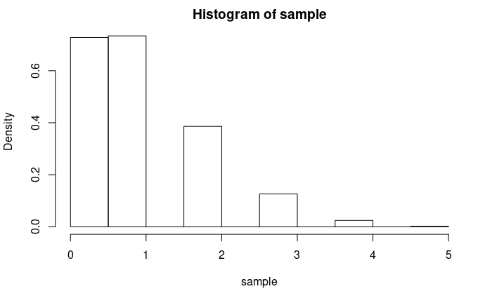

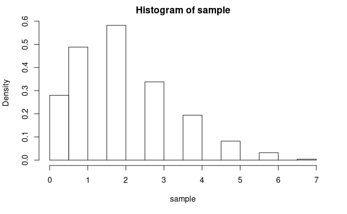

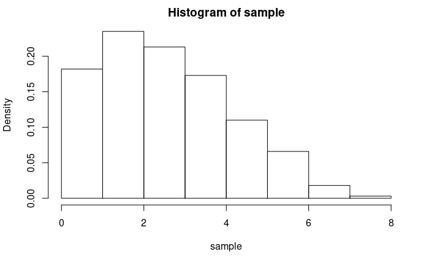

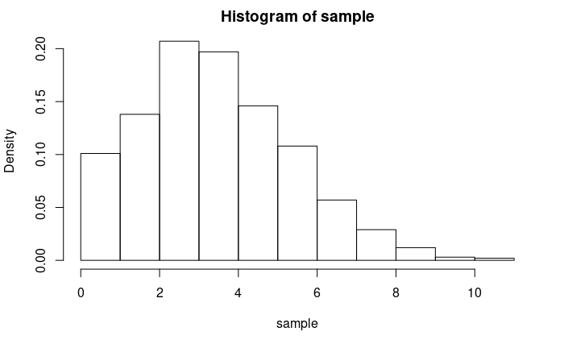

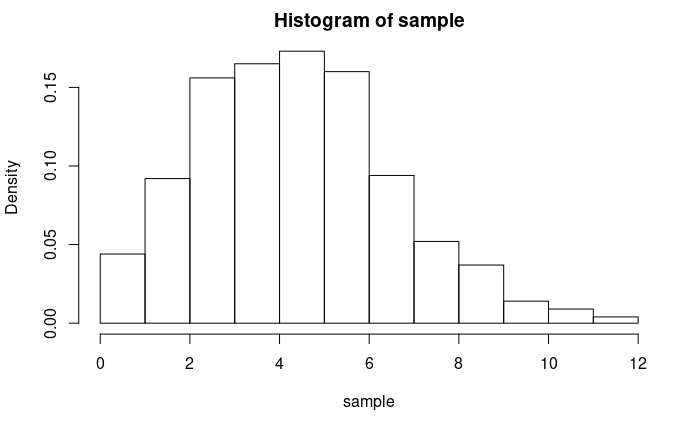

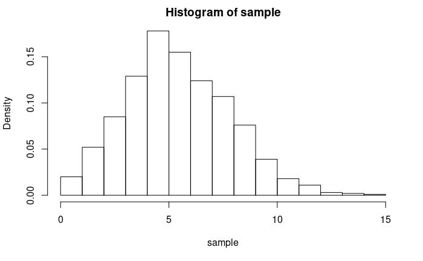

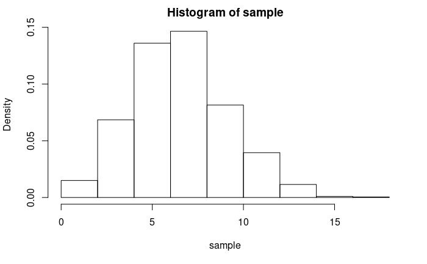

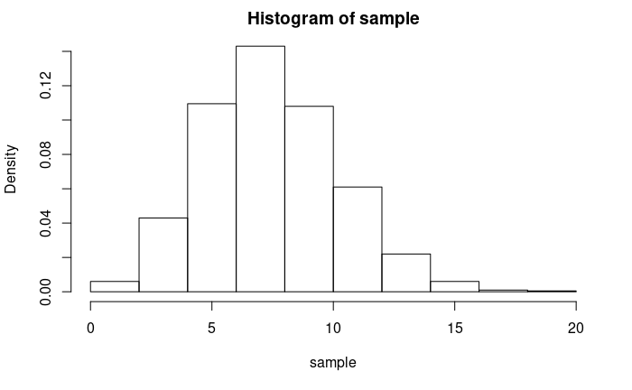

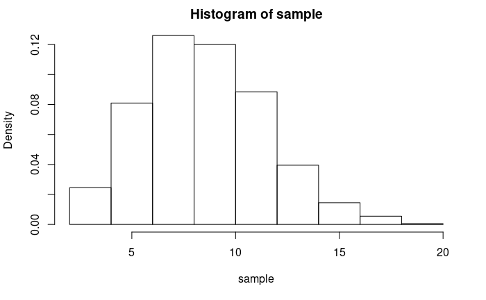

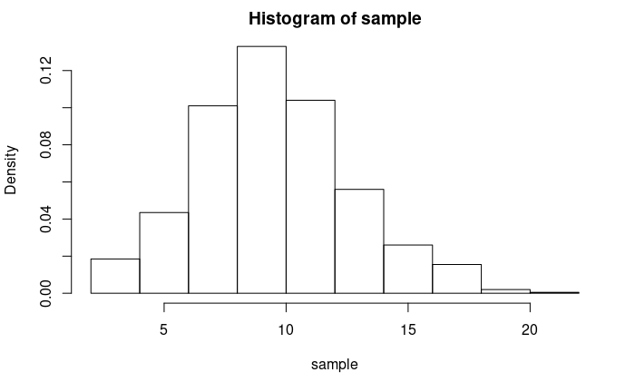

```r
for(i in 1:10) {
  sample <- rpois(1000, lambda = i)

  hist(sample, probability = 1)
}
```

```r
NA
NA
NA
```

For low number of lambda the diagram is mostly right-skwed but the more lambda increase the more it gets similar to symmetric diagram.

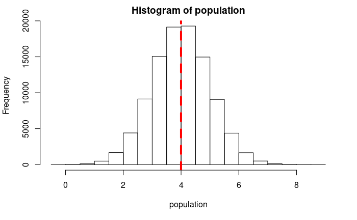

```r
population <- rnorm(100000, 4)
hist(population)
abline(v  = mean(population), col = "red", lty = 2, lwd = 4)
```

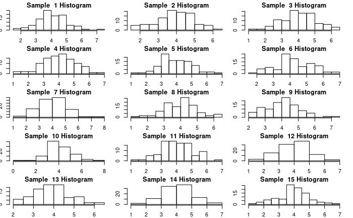

```r
par(mfrow = c(5, 3), mar = c(2, 1.5, 1.5, 1.5))
for(i in 1:15)
{
  new_sample <- sample(population, size = 100)
  hist(new_sample, main = paste("Sample ", i, "Histogram"))
}
```

[figure not shown]

```r
qqplot(new_sample, population)
abline(0, 1)
```

As we can observe in the plot data lies mostly in the 45 degree line so it is very close to the original distribution

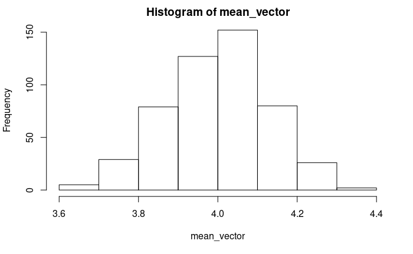

```r
mean_vector <- c()
for(i in 1:500)
{
  new_sample <- sample(population, size = 50)
  mean_vector <- c(mean_vector, mean(new_sample))
}
hist(mean_vector)
```

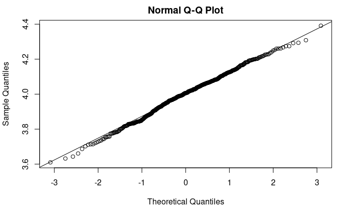

```r
qqnorm(mean_vector)
qqline(mean_vector)
```

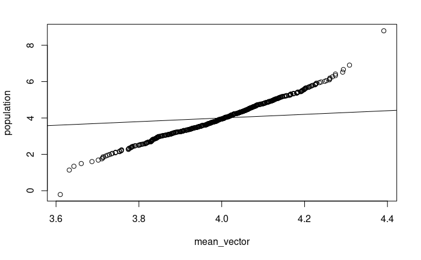

```r
qqplot(mean_vector, population)
abline(0, 1)
```

As we can see in the qqplot the distribution is very similar to normal and this has happend cause of the CLT because our sample size is less that 10% of the population and the sample size is at least 30.

If the distrobution were skewed we should sample more. But it is lessly dependent to the distrobution.

```r
print(paste("The mean is: ", mean(mean_vector)))
```

```
[1] "The mean is:  3.99831682160663"
```

```r
print(paste("The standard deviation is: ", sd(mean_vector)))
```

```
[1] "The standard deviation is:  0.129987165947309"
```

```r
print(paste("Estimation mean and sd are: ", mean(mean_vector), sd(mean_vector) * sqrt(50)))
```

```
[1] "Estimation mean and sd are:  3.99831682160663 0.919148065085635"
```

```r
print(paste("Population statistical points are: ", mean(population), sd(population)))
```

```
[1] "Population statistical points are:  3.99810756491159 0.999213844865886"
```

```r
library(mosaicData)
heights <- Galton$height
z <- -1 * qnorm((0.03)/2)
mean_heights <- mean(heights)
sd_heights <- sd(heights)
sd_heights <- sd_heights / sqrt(50)
count = 0
for(i in 1:10000)
{
  new_sample <- sample(heights, 50)
  mean_new <- mean(new_sample)
  end_interval <- mean_new + z * sd_heights
  start_interval <- mean_new - z * sd_heights
  if(mean_heights <= end_interval && mean_heights >= start_interval)
  {
    count <- count + 1
  }
}
print((count / 10000) * 100)
```

```
[1] 97.24
```

The value is very close to 97% and this is because each time the mean will lies in the confidence interval with chance of 97%. Therefore its expection value would be (97/100) * number of samples.

```r
z <- -1 * qnorm((0.1)/2)
mean_heights <- mean(heights)
sd_heights <- sd(heights)
sd_heights <- sd_heights / sqrt(10)
count <- 0
for(i in 1:10000)
{
  new_sample <- sample(heights, 10)
  mean_new <- mean(new_sample)
  end_interval <- mean_new + z * sd_heights
  start_interval <- mean_new - z * sd_heights
  if(mean_heights <= end_interval && mean_heights >= start_interval)
  {
    count <- count + 1
  }
}
print(count / 100)
```

```
[1] 90.42
```

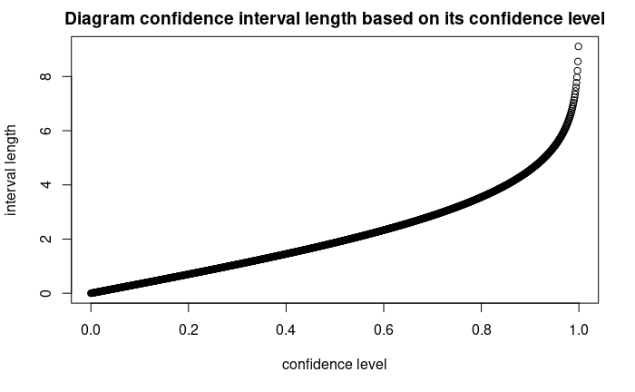

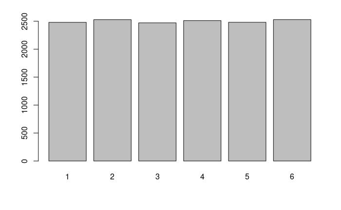

```r
outcome_dice <- c(1, 2, 3, 4, 5, 6)
vector_simulate <- sample(outcome_dice, 15000, replace = TRUE)
table_simulate <- table(vector_simulate)
barplot(table_simulate)
```

```r
count <- c(table_simulate)
count <- count / sum(count)
print(count)
```

```
        1         2         3         4         5         6
0.1653333 0.1685333 0.1647333 0.1674000 0.1654000 0.1686000
```

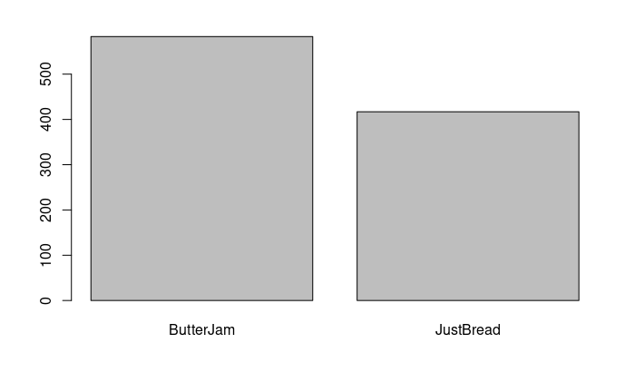

```r
outcomes <- c("ButterJam", "JustBread")
sample_toast <- sample(outcomes, 1000, replace = TRUE, prob = c(0.6, 0.4))
table_toast <- table(sample_toast)
barplot(table_toast)
```

```r
print(table_toast)
```

```
sample_toast
ButterJam JustBread
      583       417
```

```r
dice <- c(1, 2, 3, 4, 5, 6)
d1 <- sample(dice, 100000, replace = TRUE)
d2 <- sample(dice, 100000, replace = TRUE)
sum_ok <- (d1 + d2) > 8
tb_dice <- table(sum_ok)
vec_sum <- c(tb_dice)
vec_sum <- vec_sum / sum(vec_sum)
print(vec_sum)
```

[output not shown]

```r
t.test(sample_avg_humidity - 50, alternative = "two.sided", conf.level = 0.95)
```

```
    One Sample t-test

data:  sample_avg_humidity - 50
t = 4.0438, df = 730, p-value = 5.818e-05
alternative hypothesis: true mean is not equal to 0
95 percent confidence interval:
 1.561839 4.509296
sample estimates:
mean of x
 3.035568
```

The p-value is less than significance level(0.01) thus we could interpret that the null hypothesis is wrong and the humidity is not 50%.

Practicaly it is hard to reject it and this is becuase the practical signifficance is diffrent from the scientific significance level.

```r
t.test(shrimp - 33, alternative = "less", conf.level = 0.95)
```

```
    One Sample t-test

data:  shrimp - 33
t = -2.7746, df = 17, p-value = 0.00649
alternative hypothesis: true mean is less than 0
95 percent confidence interval:
       -Inf -0.4496989
sample estimates:
mean of x
-1.205556
```

Yes because p-value is less than 0.01 Therefore the alternative hypothesis is correct which is less than 33.

```r
two_tail_z_dist_mean_hyp_test(Beijing_city$avg_humidity, 50, 0.05)
```

```
[1] "P value is:  5.81823951856957e-05"
[1] "The null hypothesis has been rejected"
```

```r
two_tail_z_dist_mean_hyp_test(shrimp, 33, 0.05)
```

[output not shown]